# Data management and archival with APECS

02 Nov 2018; Tiff Stephens

### **1. Introduction**

Great work in collecting mountains of data! The next step is to make sure that we are all on the same page with how these data (and metadata) are handled so that they are accessible to other APECS members, as well prepped appropriately for long-term storage via archival. This document provides a guideline for how APECS preps data files for storage and analysis to help ensure that we meet the goals of our management plan. Each of you will help APECS reach such goals via curating the data that you collected and working with Tiff to eventually archive the data.

First, you should be aware that both grants under the APECS umbrella have a data management plan. They are not complex but serve as a promise to ourselves and to NSF that we will be responsible with the expensive data that we were funded to collect. The plans outline:

- That we will be compliant with NSF data management and dissemination policies (essentially: don’t lose data, keep it clean, and make it available to others).
- That all data is secure during the project (e.g. backed-up).
- That all datasets will be accompanied by appropriate metadata.
- That all data will be submitted to appropriate data repositories no later than two years after being collected. Eventually all should be publicly available.
- That we will submit data in an accessible and flexible format (i.e. .csv files).

**A quick summary of these guidlines**

- Make sure that your entered data are accurate and that data are stored in a “clean” format.
- Have a Masterfile for each dataset that will not be manipulated.
- Make sure that each dataset has appropriate metadata.
- Store datasets in locations accessible to all APECS members (i.e. shared Google Drive and GitHub)
- Work with Tiff to archive data with selected repositories (i.e. KNB and BCO-DMO)

Onwards! Best practices for data management with APECS:

### **2. Get those data and build, clean, and describe a dataset**

##### Enter data

After fieldwork, labwork, etc., collate the raw data into a spreadsheet. Be mindful, however, how those data are entered/organized into a working dataset. A spiffy dataset is a “clean” dataset (see below). It saves *a lot* of time to enter it in such a way that the data (1) are readily accessble to whatever statistical software you plan to use and (2) readily accessible to future users. For archival, the data eventually need to be structured into a format that happens to align with structure appropriate for R.

*What is a clean dataset?* Essentially, each variable (dependent and independent) should have its own column, where the rows in each column includes a single point of information. Columns can have multiple factors included to help characterize a single datapoint – for example a “sea_otter_region” column can have “high”, “mid”, “low” factors within them. Further examples/guidlines are described below, paired with the following image:

**A.** Column titles and text in rows: Some packages, like R, do not like spaces in the titles for columns/variable, instead use an underscore or period between words/characters. Typically, spaces in rows/factors is just fine.

**B.** It’s easiest to keep lats and longs in decimal degrees.

**C.** For dates, please annotate what format your data are in, especially in the metadata but it is also useful for column titles. e.g. “MM.DD.YY”, “YYYY.MM.DD”. Date data are notorious troublemakers in both analysis and archival, especially for international access.

**D.** These columns are examples of how multiple factors can be included in one column, notice how the information is nested…i.e. that each replicate is nested within its respective transect, nested within the respective site. Depending on your preference, these different factors can occupy separate columns (like shown with the density data in columns K and L).

**E.** Note that if there are site-level data, such needs to be filled in for EVERY unique datapoint; its OK if it looks repetitive.

**F.** Two issues here: (1) running calculations in Excel and (2) saving files with calculation sections (see bottom of columns). Unless you’re running data analysis in Excel (please don’t do this), there should be no calculations saved in the spreadsheet (these won’t be saved in a .csv, anyway). If you’re using R for analysis, please avoid calculating anything in Excel, even simple sums or means…mistakes will happen. In this example, it is better to leave the two density columns as raw and calculate their mean using code in R (this is reproducible and more reliable). The second issue will be misinterpretted by your statistical software; whatever platform you use incorporates information from the entire column called upon and thus would include “Averages”, “Nossuk”, “N Pass”, and “Shinaku” as factors in the sediment columns, and the associated mean values as new datapoints in the pits column. Just don’t do these things.

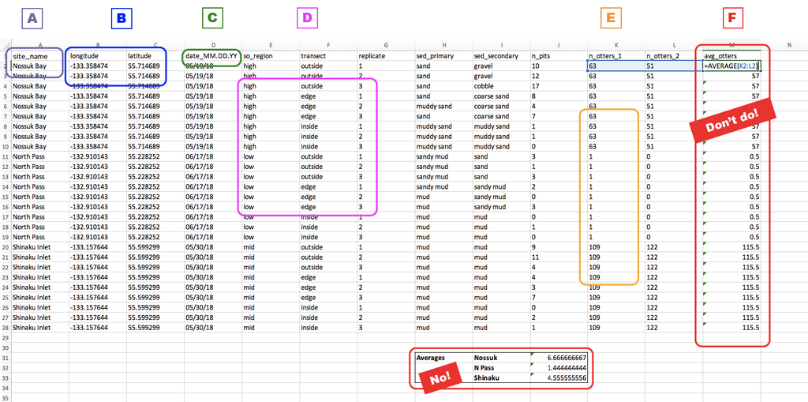

Neat. Please see Tiff or Wendel if you have any questions about this.

##### Don’t forget to QC/QA.

It’s necessary to check ALL of the entered data with assure that it is accurate…hopefully it goes faster than the initial entry. Even after verifying everything, I like to go through the dataset in R to see if there are any odd entries or values that don’t make sense before fully accepting that the QC/QA process in complete. There are a lot of ways to check data but I at least like to make sure that functions like “summary()” work without errors and manually sort each column to check for errors (e.g. odd placement of “NA” or accidental character included, like an “.” instead of “0” or “NA”).

##### Metadata!

It is also critical to build metadata for each datasheet, for both APECS and for data archival. What do I mean by meta data? Two things:

- **Short, direct definitions**: This often involves transposing the column titles that you have and providing an informative definition/description of each factor in your datasheet (example below). This can be saved as a seperate tab in an Excel document but will ultimately need to be a separate .csv file to pair with your data for archival.

  | Factor | Description |
  | --- | --- |
  | site_name | Identifying name of the field site |
  | longitude | Longitude (E) of the site in decimal degrees |
  | latitude | Latitude (N) of the site in decimal degrees |
  | date_MM.DD.YY | Date of sampling expressed as month, day, and year (MM/DD/YY) |
  | so_region | Regional categorization of sea otter presence; 3 levels: “high”, “mid”, “low” |
  | transect | Transect location within each site relative to the seagrass bed |
  | replicate | Replicate number within each transect |
  | sed_primary | Qualitative characterization of the primary sediment type (e.g. sand, mud) |
  | sed_secondary | Qualitative characterization of the secondary sediment type |
  | n_pits | Number of pits counted within the transect replicate |
  | n_otters1 | Number of sea otters counted in the first boat survey |
  | n_otters2 | Number of sea otters counted in the second boat survey |

- **Brief summaries**: This should include information about the purpose of the dataset and basic summaries of where and how it was collected. Think “briefer version of the methods section”. This is an extremely valuable description for people that will access the publicly available data years down the road, and can be the clencher for whether your data are usable/interpretable by future parties. This is a requirement for submitting to data repositories, a real-life KNB example shown below:

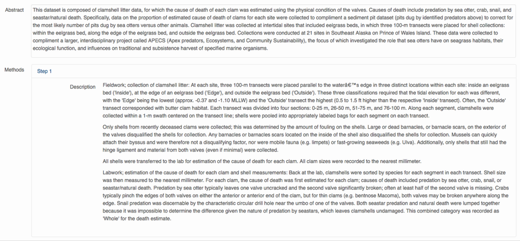

### **3. Day-to-day storage of data**

The two most important things to do remember when storing data are to keep a **Masterfile** of the each datasheet (after QC/QA) that will not be manipulated and to not lose the data. There are two places that we store data so that it is safe and accessible by APECS members: the shared Google Drive and GitHub platforms that APECS curates. Backing-up data on personal/lab hard drives and computers is also approprate ( if not inevitable). Keep in mind, however, that it is important to be weary and conscious of multiple file versions. In the end, APECS *really* only wants two versions of the datasheet (i.e. raw and clean) for APECS-related storage and analysis, and that can get messy if you have 20 different versions of the same file.

- **Google Drive**: I think that we’re all familiar with this, already, since many have their own folder within the data folder in the shared drive. If you don’t have one, please start one, and if you don’t have access, please ask me for it. It’s fine to leave these files as google files (as opposed to .csv), but it is important to have obvious names for each file, noting whether it is raw or clean.

[figure not shown]

[figure not shown]

- **GitHub**: Tiff and Wendel have been working from the APECS GitHub folder, meaning that in addition to storage in the Google Drive, we store datasets in the “APECS-master-repos” folder to call upon in RStudio (or R) for data manipulation and analysis. We held a workshop on this last year but since few people had datasets to practice with, it is 100% understandable and recomended to consult with either Tiff or Wendel if you want to get in on the GitHub stoke. As a reminder, you’ll want to have a local GitHub folder system on your local computer that links to the online GitHub repository.

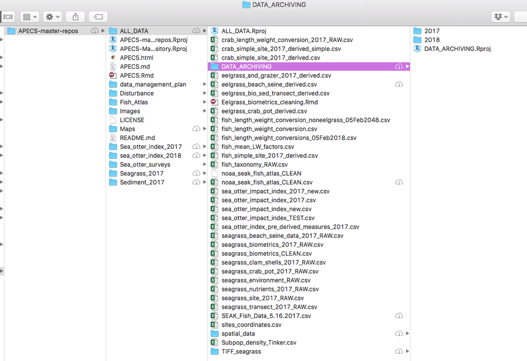

### **4. Long-term archival of data**

Generally, you will work with Tiff to successfully upload all APECS-collected data into our preferred data repositories. In our data management plan with NSF, we committed to archiving our data to BCO-DMO ([Biological and Chemical Oceanography Data Management Office](https://www.bco-dmo.org/)) but are also submitting to KNB ([Knowledge Network for Biocomplexity](https://knb.ecoinformatics.org/)). The latter is more user friendly and the archived data is accessible to BCO-DMO.

The important prep information for data archival was largely covered in the section about data structure and metadata. These are critical for archival. The following files should be submitted for archival:

- Dataset that is cleaned (required)
- Metadata (required)
- Raw dataset (optional but great for reproducibility)
- Code used to transform raw data into working data (optional but great for reproducibility)
- Diagram to help convey methods for data collection (optional)

There isn’t much more to say here other than archival is a serious business and it’s best to be thorough because you don’t know who will access your dataset, what they’ll use it for, and whether you’ll still be alive if they have questions. You can look at an example from last year, where [Tiff archived 2017 data using a series of submissions to KNB](https://knb.ecoinformatics.org/view/knb.92121.19). *Note: KNB has been updating their user platform a lot, recently, so even Tiff needs to give it a new browse to make sure that functionality is as she knows it.*